# Pytorch Examples

*Author : maxime.savary@orange.com (v1.0 December 2020)*

The objective of this section is to present examples of implementation with the **Pytorch** framework.

In practice, the implementation of a neural network in Python can be based on frameworks. There are 2 major ones:

- Tensorflow (https://www.tensorflow.org/) developed by Google
- Pytorch (https://pytorch.org/) developed by Facebook

*These two frameworks have different philosophies. Tensorflow is very robust and has powerful tools to visualize learning curves and weight history but its high level approach is a bit confusing. Pytorch is more algorithmic and sticks to the theory in the stages. We thus keep a clear vision of what is happening. This is the objective sought here*

## XOR again ...

We get back to the XOR

### NN = (2, 2, 1)

We make an implementation with 1 hidden Layer with 2 Neurones + 1 Output

**Algorithm** :

1. We create X,y tensors from the truth table
2. We create the class representing the NN (2,2,1) with 1 hidden Layer
3. Cost Function = Mean Square
4. Optimizer = Stochastic Gradient Descent
5. We loop on training data set
6. Trace error value for each iteration

There is indeed convergence towards an error close to 0. The last predicted value is in conformity with the expected truth table

```
[[3.961727  3.9910784]
 [6.0974264 6.2481275]]
tensor([[0.0395],
        [0.9648],
        [0.9645],
        [0.0376]], grad_fn=<SigmoidBackward>)
```

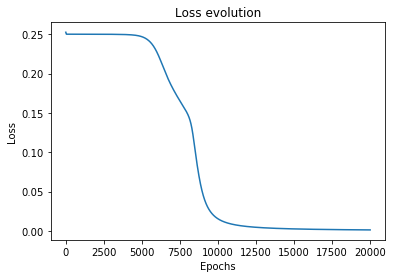

```python
import sklearn
import numpy as np
import pandas as pd
from sklearn.preprocessing import StandardScaler

import torch
from torch.autograd import Variable
import matplotlib.pyplot as plt


# Batch : Training examples
X = np.array([[0,0],[0,1],[1,0],[1,1]])
y = np.array([0,1,1,0])

# Transform X,y in Tensor
t_XTrain = Variable(torch.Tensor(X).float())
t_yTrain = Variable(torch.Tensor(y).float())



# Model with 2 Layers
class MyXOR(torch.nn.Module):
    # Constructor
    def __init__(self):
        super(MyXOR,self).__init__()
        # Layer_1 (2 Inputs, 2 Neurones)
        self.layer1 = torch.nn.Linear(2,2)
        self.ft1 = torch.nn.Sigmoid()
        # Layer_2 (2 Neurones / 1 output)
        self.layer2 = torch.nn.Linear(2,1)
        self.ft2 = torch.nn.Sigmoid()

    # MyXOR Neural Network output calculus
    def forward(self,x):
        # L1 output : Linear combinaison + sigmoid
        out = self.layer1(x)
        out = self.ft1(out)
        # L2 output : Linear combinaison of + sigmoid
        out = self.layer2(out)
        out = self.ft2(out)
        return out

# Instanciate Loss Function : Mean Squared Error
loss_func = torch.nn.MSELoss()
# Instanciate Neural Network
model = MyXOR()
# Stochastic Gradient Descent
optimizer = torch.optim.SGD(model.parameters(), lr=0.02, momentum=0.9)


# Train .......
n_epochs = 20000
losses = np.zeros(n_epochs)

for iter in range(n_epochs):
    # reset of gradient
    optimizer.zero_grad()
    # Compute NN output
    yPred = model.forward(t_XTrain)
    # Compute Loss
    loss = loss_func(yPred.squeeze(), t_yTrain)
    losses[iter] = loss.item()
    # Backpropagation
    loss.backward()
    # Weights update
    optimizer.step()


# Weights and Bias
model_params = list(model.parameters())
model_weights = model_params[0].data.numpy()
model_bias = model_params[1].data.numpy()
print(model_weights)

print(yPred)

# Plot Loss
plt.plot(np.arange(0, losses.shape[0]), losses)
plt.title("Loss evolution")
plt.xlabel("Epochs")
plt.ylabel("Loss")
plt.show()
```

### NN = (2, 5, 8, 1)

**Algorithm** : Same as above

```
[[ 0.6368259  -0.52017987]
 [ 0.5412452  -0.9024133 ]
 [ 0.32906616  0.10554735]
 [ 0.58768445  0.06268177]
 [ 2.4822667  -2.8631291 ]]
tensor([[0.4438],
        [0.4345],
        [0.6683],
        [0.4211]], grad_fn=<SigmoidBackward>)
```

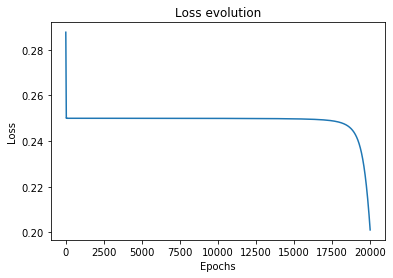

```python
import sklearn
import numpy as np
import pandas as pd
from sklearn.preprocessing import StandardScaler

import torch
from torch.autograd import Variable
import matplotlib.pyplot as plt


# Batch : Training examples
X = np.array([[0,0],[0,1],[1,0],[1,1]])
y = np.array([0,1,1,0])

# Transform X,y in Tensor
t_XTrain = Variable(torch.Tensor(X).float())
t_yTrain = Variable(torch.Tensor(y).float())


# Model with 2 Layers
class MyXOR(torch.nn.Module):
    # Constructor
    def __init__(self):
        super(MyXOR,self).__init__()
        # Layer_1 (2 Inputs / 5 neurones)
        self.layer1 = torch.nn.Linear(2,5)
        self.ft1 = torch.nn.Sigmoid()
        # Layer_2 (5 Neurones / 8 Neurones)
        self.layer2 = torch.nn.Linear(5,8)
        self.ft2 = torch.nn.Sigmoid()
        # Layer_3 (8 neurones / 1 Output)
        self.layer3 = torch.nn.Linear(8,1)
        self.ft3 = torch.nn.Sigmoid()

    # MyXOR Neural Network output calculus
    def forward(self,x):
        # L1 output : Linear combinaison + sigmoid
        out = self.layer1(x)
        out = self.ft1(out)
        # L2 output : Linear combinaison of + sigmoid
        out = self.layer2(out)
        out = self.ft2(out)
        # L3
        out = self.layer3(out)
        out = self.ft3(out)
        return out

# Instanciate Loss Function : Mean Squared Error
loss_func = torch.nn.MSELoss()
# Instanciate Neural Network
model = MyXOR()
# Stochastic Gradient Descent
optimizer = torch.optim.SGD(model.parameters(), lr=0.02, momentum=0.9)


# Train .......
n_epochs = 20000
losses = np.zeros(n_epochs)

for iter in range(n_epochs):
    # reset of gradient
    optimizer.zero_grad()
    # Compute NN output
    yPred = model.forward(t_XTrain)
    # Compute Loss
    loss = loss_func(yPred.squeeze(), t_yTrain)
    losses[iter] = loss.item()
    # Backpropagation
    loss.backward()
    # Weights update
    optimizer.step()


# Weights and Bias
model_params = list(model.parameters())
model_weights = model_params[0].data.numpy()
model_bias = model_params[1].data.numpy()
print(model_weights)

print(yPred)

# Plot Loss
plt.plot(np.arange(0, losses.shape[0]), losses)
plt.title("Loss evolution")
plt.xlabel("Epochs")
plt.ylabel("Loss")
plt.show()
```

## The OR

We implement the logical **OR** with the same architecture as **XOR** = (2,2,1)

the truth table is :

| $A$ | $B$ | OR |
| --- | --- | --- |
| 0 | 0 | 0 |
| 1 | 0 | 1 |
| 0 | 1 | 1 |
| 1 | 1 | 1 |

**Algorithm** : same as above

The output model "sticks" to the expected truth table

**=>** The same architecture can model different problems

### NN = (2, 2, 1)

```
[[-3.7412367 -3.605078 ]
 [ 3.054218   3.2039878]]
tensor([[0.0203],
        [0.9857],
        [0.9856],
        [0.9967]], grad_fn=<SigmoidBackward>)
```

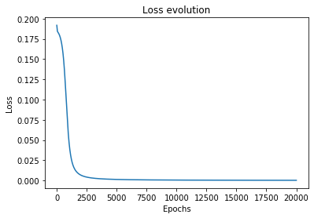

```python
import sklearn
import numpy as np
import pandas as pd
from sklearn.preprocessing import StandardScaler

import torch
from torch.autograd import Variable
import matplotlib.pyplot as plt


# Batch : Training examples
X = np.array([[0,0],[0,1],[1,0],[1,1]])
y = np.array([0,1,1,1])

# Transform X,y in Tensor
t_XTrain = Variable(torch.Tensor(X).float())
t_yTrain = Variable(torch.Tensor(y).float())


# Model with 2 Layers
class MyXOR(torch.nn.Module):
    # Constructor
    def __init__(self):
        super(MyXOR,self).__init__()
        # Layer_1 (2 Inputs, 2 Neurones)
        self.layer1 = torch.nn.Linear(2,2)
        self.ft1 = torch.nn.Sigmoid()
        # Layer_2 (2 Neurones / 1 output)
        self.layer2 = torch.nn.Linear(2,1)
        self.ft2 = torch.nn.Sigmoid()

    # MyXOR Neural Network output calculus
    def forward(self,x):
        # L1 output : Linear combinaison + sigmoid
        out = self.layer1(x)
        out = self.ft1(out)
        # L2 output : Linear combinaison of + sigmoid
        out = self.layer2(out)
        out = self.ft2(out)
        return out

# Instanciate Loss Function : Mean Squared Error
loss_func = torch.nn.MSELoss()
# Instanciate Neural Network
model = MyXOR()
# Stochastic Gradient Descent
optimizer = torch.optim.SGD(model.parameters(), lr=0.02, momentum=0.9)


# Train .......
n_epochs = 20000
losses = np.zeros(n_epochs)

for iter in range(n_epochs):
    # reset of gradient
    optimizer.zero_grad()
    # Compute NN output
    yPred = model.forward(t_XTrain)
    # Compute Loss
    loss = loss_func(yPred.squeeze(), t_yTrain)
    losses[iter] = loss.item()
    # Backpropagation
    loss.backward()
    # Weights update
    optimizer.step()


# Weights and Bias
model_params = list(model.parameters())
model_weights = model_params[0].data.numpy()
model_bias = model_params[1].data.numpy()
print(model_weights)

print(yPred)

# Plot Loss
plt.plot(np.arange(0, losses.shape[0]), losses)
plt.title("Loss evolution")
plt.xlabel("Epochs")
plt.ylabel("Loss")
plt.show()
```

## Iris Classification

We are looking here at a more realistic classification case based on the Iris dataset : https://en.wikipedia.org/wiki/Iris_flower_data_set

The Dataset consists of 150 entries representing 4 plants characteristics and their classification

- sepal length (cm)
- sepal width (cm)
- petal length (cm)
- petal width (cm)
- species : 'setosa (0)' 'versicolor (1)' 'virginica (2)'

### NN = (4, 6, 3)

We make an implementation with 1 Hidden Layer with 6 Neurones + 1 Output (3-dim Vector)

**Algorithm** :

- Same structure as for the previous ones
- The Iris dataset is loaded with *sklearn* Library. It is split into *train* ($80\%$) and *test* ($20\%$).
- We map the *species* as follows : `'0' = [1, 0, 0]`, `'1' = [0, 1, 0]`, `'2' = [0, 0, 1]`
- The Output `y_test_pred` is a Tensor (a List) of vectors of dimension 3 representing the category intended by the model. We have things like `[0.97, 0.026, 0.00023]` representing `[1, 0, 0]`
- We calculate the accuracy score of the test set which represents the compliance rate between the values predicted by the model and the expected values $1 = 100\%$

There is indeed convergence towards an error close to 0.

```
['setosa' 'versicolor' 'virginica']
Accuracy score on Test data set :  0.9666666666666667
```

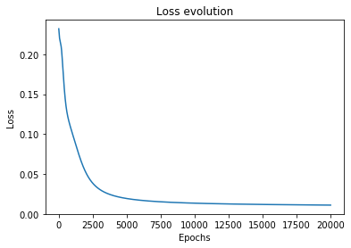

```python
from sklearn import datasets
from sklearn.model_selection import train_test_split
from sklearn.metrics import accuracy_score, precision_score, recall_score

import torch
from torch.autograd import Variable

import matplotlib.pyplot as plt
import numpy as np


# Load Iris data set
iris = datasets.load_iris()

print(iris.target_names)

# Generate class label datas from Iris target
class_labels = []
for t in iris.target:
    if t == 0:
        class_labels.append([1, 0, 0]) # setosa
    if t == 1:
        class_labels.append([0, 1, 0]) # versicolor
    if t == 2:
        class_labels.append([0, 0, 1]) # virginica

class_labels = np.array(class_labels, dtype=int)


X_train, X_test, y_train, y_test = train_test_split(iris.data, class_labels, test_size=0.2)


t_XTrain = Variable(torch.FloatTensor(X_train))
t_XTest = Variable(torch.FloatTensor(X_test))
t_yTrain = Variable(torch.FloatTensor(y_train))
t_yTest = Variable(torch.FloatTensor(y_test))


# Model with 2 Layers
class IrisNet(torch.nn.Module):
    # Constructor
    def __init__(self):
        super(IrisNet,self).__init__()
        self.layer1 = torch.nn.Linear(4,6)
        self.ft1 = torch.nn.Sigmoid()
        self.layer2 = torch.nn.Linear(6,3)
        self.ft2 = torch.nn.Softmax(dim=1)

    # MyXOR Neural Network output calculus
    def forward(self,x):
        out = self.layer1(x)
        out = self.ft1(out)
        out = self.layer2(out)
        out = self.ft2(out)
        return out


# Instanciate Loss Function : Mean Squared Error
loss_func = torch.nn.MSELoss()
# Instanciate Neural Network
model = IrisNet()
# Stochastic Gradient Descent
optimizer = torch.optim.SGD(model.parameters(), lr=0.01, momentum=0.9)


# Train .......
n_epochs = 20000
losses = np.zeros(n_epochs)

for iter in range(n_epochs):
    optimizer.zero_grad()
    yPred = model.forward(t_XTrain)
    loss = loss_func(yPred, t_yTrain)
    losses[iter] = loss.item()
    loss.backward()
    optimizer.step()

# Test the model ...
y_test_pred = model(t_XTest)
r_ytp = torch.argmax(y_test_pred, dim=1).numpy()
r_yt = torch.argmax(t_yTest, dim=1).numpy()
score = accuracy_score(r_ytp, r_yt)

print("Accuracy score on Test data set : ",score)


# Plot Loss
plt.plot(np.arange(0, losses.shape[0]), losses)
plt.title("Loss evolution")
plt.xlabel("Epochs")
plt.ylabel("Loss")
plt.show()
```